# Analyse des données ménages - Sect1 Harvest W4

DIALLO Mamadou Moussa - DIOP Papa Boubacar

2026-03-17

```r
# Importation des packages
library(haven)
library(dplyr)
library(ggplot2)
library(apyramid)
library(naniar)
library(gtsummary)
library(rstatix)
library(PropCIs)
library(patchwork)
library(tidyr)
library(purrr)
```

```r
# Chargement des données
data <- read_stata("../data/raw/sect1_harvestw4.dta")
data_2 <- read_stata("../data/raw/secta_harvestw4.dta")
```

# Exploration initiale des données

## Vérification des doublons

```r
data %>% count(hhid, indiv) %>% filter(n > 1) %>% count()
```

```
## # A tibble: 1 × 1
##       n
##   <int>
## 1     0
```

## Valeurs manquantes

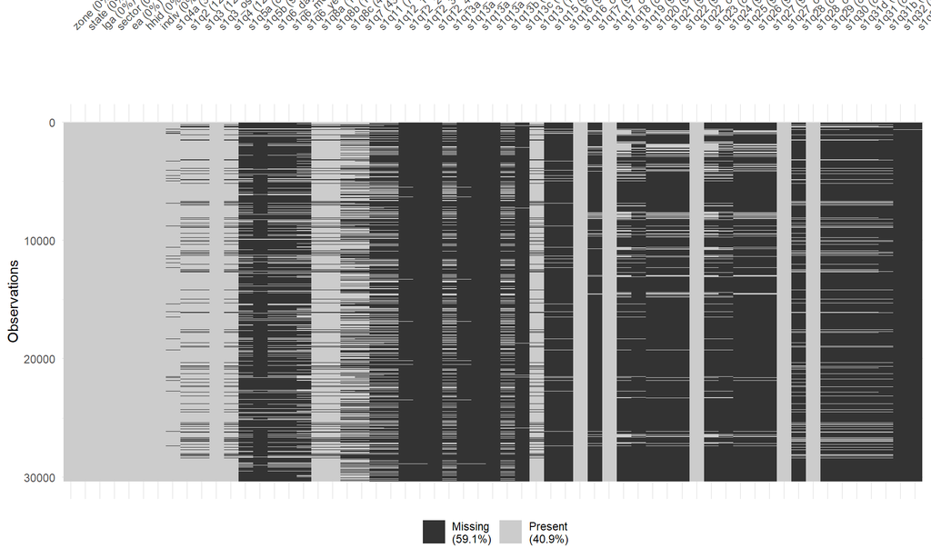

```r
vis_miss(data, warn_large_data = F)
```

# Analyse univariée de l’âge des membres

## Visualisations

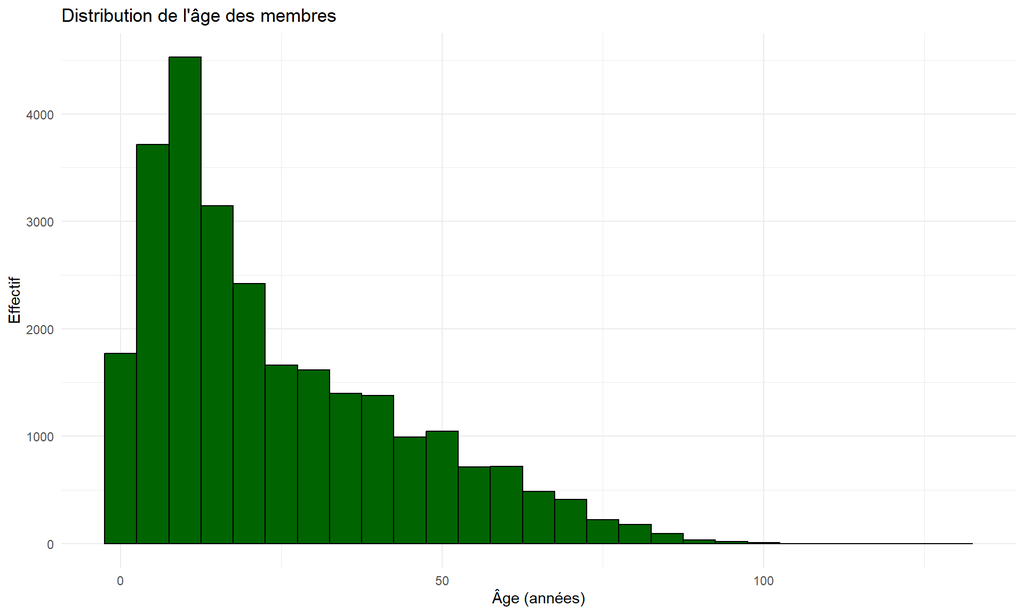

```r
# Histogramme avec des classes de 5 ans
ggplot(data, aes(x = s1q4)) +
  geom_histogram(binwidth = 5, fill = "darkgreen", color = "black") +
  labs(
    title = "Distribution de l'âge des membres",
    x = "Âge (années)",
    y = "Effectif"
  ) +
  theme_minimal()
```

L’histogramme montre la répartition des âges des membres des ménages par tranches de 5 ans. On peut observer que certaines tranches sont plus représentées, ce qui permet de voir si la population est plutôt jeune ou âgée. Ce graphique aide à comprendre la structure d’âge dominante et à détecter d’éventuelles anomalies dans les données. Ces informations sont utiles pour analyser d’autres aspects du ménage, comme le niveau d’éducation ou la participation à l’activité économique.

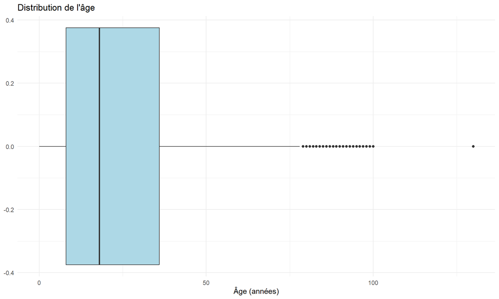

```r
# Boîte à moustaches
ggplot(data, aes(x = s1q4)) +
  geom_boxplot(fill = "lightblue") +
  labs(
    title = "Distribution de l'âge",
    x = "Âge (années)"
  ) +
  theme_minimal()
```

La boîte à moustaches illustre la distribution des âges des membres des ménages. Elle montre la médiane, le 1er et 3e quartile, ainsi que les valeurs extrêmes. On peut ainsi visualiser rapidement si les âges sont concentrés autour de la médiane ou dispersés, et identifier d’éventuelles valeurs atypiques (très jeunes ou très âgés). Ce graphique complète l’histogramme en donnant une vision plus précise de la répartition et de la variabilité des âges.

## Statistiques descriptives

```r
stat_desc_age <- data %>%
  select(s1q4) %>%
  tbl_summary(
    type = s1q4 ~ "continuous2",
    statistic = all_continuous() ~ c("{mean}", "{median}", "{p25}", "{p75}"),
    label = s1q4 ~ "Âge"
  )
stat_desc_age
```

| **Characteristic** | **N = 30,337** |
| --- | --- |
| Âge |  |
| Mean | 24 |
| Median | 18 |
| Q1 | 8 |
| Q3 | 36 |
| Unknown | 3,780 |

Analyse : Le code calcule des statistiques descriptives pour la variable s1q4 (étiquetée « Âge ») dans le jeu de données data. Il utilise le package gtsummary (tbl_summary) pour produire :

Moyenne (mean)

Médiane (median)

1er quartile (p25)

3e quartile (p75)

Ces statistiques donnent un aperçu central et de dispersion de l’âge des individus.

Interprétation :

La moyenne indique l’âge moyen des participants.

La médiane montre l’âge qui sépare la moitié inférieure de la moitié supérieure.

Les quartiles (25% et 75%) permettent de comprendre la répartition et la variabilité des âges. ## Test de normalité

```r
# Test de Shapiro-Wilk (taille de l'échantillon est supérieur à 5)
# shapiro.test(data$s1q4)
```

Interprétation :

Si exécuté, shapiro.test(data$s1q4) testerait l’hypothèse nulle : les données suivent une distribution normale.

Un p-value > 0,05 ⇒ on ne rejette pas l’hypothèse nulle ⇒ les âges peuvent être considérés comme normaux.

Un p-value ≤ 0,05 ⇒ on rejette l’hypothèse ⇒ distribution non normale.

En résumé, ce code est prévu pour vérifier si la variable Âge suit une loi normale, mais pour l’instant le test est désactivé. # Pyramide des âges

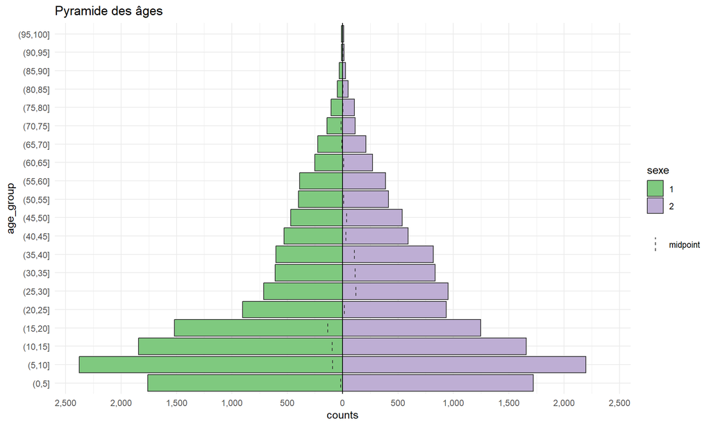

```r
data_pyramid <- data %>%
  select(age = s1q4, sexe = s1q2) %>%
  filter(!is.na(age), !is.na(sexe)) %>%
  mutate(age_group = cut(age, breaks = seq(0, 100, by = 5)))

age_pyramid(data_pyramid, age_group = age_group, split_by = sexe) +
  labs(title = "Pyramide des âges") +
  theme_minimal()
```

Le code crée une pyramide des âges à partir du jeu de données data :

Sélection et nettoyage : on garde seulement les colonnes s1q4 (Âge) et s1q2 (Sexe), et on retire les valeurs manquantes.

Visualisation : age_pyramid() génère la pyramide des âges en séparant les hommes et les femmes (split_by = sexe), avec un titre et un thème minimal.

Interprétation :

La pyramide montre la répartition de la population par âge et par sexe.

Les barres horizontales vers la gauche représentent un sexe (souvent les hommes), vers la droite l’autre sexe (souvent les femmes).

Elle permet de visualiser :

Les classes d’âge les plus peuplées.

La proportion hommes/femmes dans chaque tranche.

La structure démographique globale (jeune, adulte, vieillissante).

En résumé, ce code produit un graphique clair pour analyser la composition par âge et sexe dans ton échantillon.

## Diagramme en barres simple

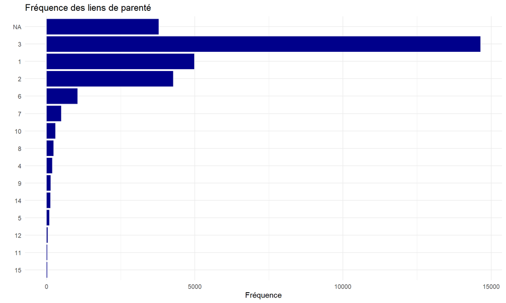

```r
data %>%
  count(s1q3) %>%
  arrange(desc(n)) %>%
  ggplot(aes(x = n, y = reorder(s1q3, n))) +
  geom_col(fill = "darkblue") +
  labs(
    title = "Fréquence des liens de parenté",
    x = "Fréquence",
    y = ""
  ) +
  theme_minimal()
```

Analyse : Le code crée un diagramme en barres pour la variable s1q3 (liens de parenté) :

count(s1q3) : calcule le nombre d’occurrences pour chaque type de lien de parenté.

arrange(desc(n)) : trie les résultats par fréquence décroissante.

ggplot(…) + geom_col(…) : génère un graphique à barres horizontales, avec n sur l’axe x et les types de parenté sur l’axe y, coloré en bleu foncé.

labs() et theme_minimal() : ajout du titre et style minimaliste.

Interprétation :

Chaque barre représente la fréquence d’un lien de parenté dans l’échantillon.

Les liens les plus fréquents apparaissent en haut.

Cela permet de visualiser rapidement quels types de membres du ménage sont les plus représentés (ex. père, mère, enfant…).

En résumé, ce code sert à analyser visuellement la composition des ménages par type de parenté. ## Proportions avec intervalles de confiance

```r
total <- nrow(data)

resultats_parente <- data %>%
  filter(!is.na(s1q3)) %>%
  count(s1q3, name = "effectif") %>%
  mutate(
    proportion = effectif / total,
    proportion_pct = scales::percent(proportion, accuracy = 0.1),
    IC_lower = sapply(effectif, function(x) scoreci(x, total, conf.level = 0.95)$conf.int[1]),
    IC_upper = sapply(effectif, function(x) scoreci(x, total, conf.level = 0.95)$conf.int[2]),
    IC_text = paste0("[", scales::percent(IC_lower, accuracy = 0.1), " ; ",
                     scales::percent(IC_upper, accuracy = 0.1), "]")
  )

# Affichage du tableau
resultats_parente %>%
  select(s1q3, effectif, proportion_pct, IC_text) %>%
  rename(
    `Lien de parenté` = s1q3,
    Effectif = effectif,
    Proportion = proportion_pct,
    `IC 95%` = IC_text
  )
```

```
## # A tibble: 14 × 4
##    `Lien de parenté`                     Effectif Proportion `IC 95%`
##    <dbl+lbl>                                <int> <chr>      <chr>
##  1  1 [1. HEAD]                              4980 16.4%      [16.0% ; 16.8%]
##  2  2 [2. SPOUSE]                            4273 14.1%      [13.7% ; 14.5%]
##  3  3 [3. OWN CHILD]                        14636 48.2%      [47.7% ; 48.8%]
##  4  4 [4. STEP CHILD]                         192 0.6%       [0.6% ; 0.7%]
##  5  5 [5. ADOPTED CHILD]                       88 0.3%       [0.2% ; 0.4%]
##  6  6 [6. GRANDCHILD]                        1045 3.4%       [3.2% ; 3.7%]
##  7  7 [7. BROTHER/SISTER]                     487 1.6%       [1.5% ; 1.8%]
##  8  8 [8. NIECE/NEPHEW]                       229 0.8%       [0.7% ; 0.9%]
##  9  9 [9. BROTHER/SISTER-IN-LAW]              137 0.5%       [0.4% ; 0.5%]
## 10 10 [10. PARENT]                            291 1.0%       [0.9% ; 1.1%]
## 11 11 [11. PARENT-IN-LAW]                      20 0.1%       [0.0% ; 0.1%]
## 12 12 [12. DOMESTIC HELP]                      39 0.1%       [0.1% ; 0.2%]
## 13 14 [14. OTHER RELATION (SPECIFY)]          123 0.4%       [0.3% ; 0.5%]
## 14 15 [15. OTHER NON-RELATION (SPECIFY)]       17 0.1%       [0.0% ; 0.1%]
```

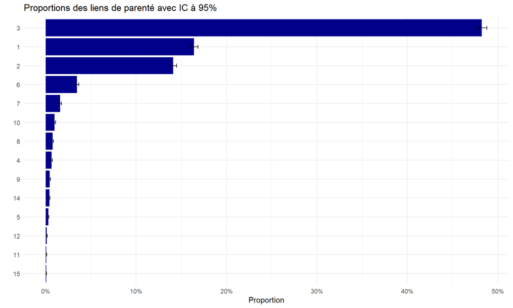

```r
# Visualisation avec IC
resultats_parente %>%
  ggplot(aes(x = proportion, y = reorder(s1q3, proportion))) +
  geom_col(fill = "darkblue") +
  geom_errorbar(aes(xmin = IC_lower, xmax = IC_upper), width = 0.2) +
  labs(
    title = "Proportions des liens de parenté avec IC à 95%",
    x = "Proportion",
    y = ""
  ) +
  scale_x_continuous(labels = scales::percent) +
  theme_minimal()
```

Analyse : Le code calcule et visualise les proportions des liens de parenté (s1q3) avec intervalle de confiance (IC) à 95% :

total <- nrow(data) : nombre total d’individus.

count(s1q3) : compte le nombre d’occurrences par lien de parenté.

mutate(…) :

Calcule la proportion et la proportion en pourcentage.

Calcule les IC à 95% pour chaque proportion avec scoreci().

Crée une colonne texte résumant l’IC (IC_text).

Affiche un tableau clair avec lien de parenté, effectif, proportion et IC.

ggplot(…) + geom_col() + geom_errorbar() : crée un graphique à barres horizontales avec les IC visibles.

Interprétation :

Le tableau montre combien de personnes appartiennent à chaque type de lien de parenté et la proportion correspondante.

Les IC permettent de juger la précision de ces proportions dans l’échantillon.

Le graphique facilite la lecture visuelle, montrant les liens les plus fréquents et la variabilité estimée.

En résumé, ce code permet de quantifier et visualiser la composition du ménage par type de lien familial, avec un indicateur statistique de confiance. # Comparaison de la taille des ménages entre zones rurales et urbaines

## Préparation des données

```r
# Calcul de la taille des ménages
data_group <- data %>%
  select(hhid) %>%
  group_by(hhid) %>%
  summarise(taille_men = n())

# Jointure avec les données de zone
data_group <- inner_join(data_group, data_2, by = "hhid")
```

nalyse : Le code calcule la taille des ménages :

select(hhid) : on garde seulement l’identifiant du ménage.

group_by(hhid) %>% summarise(taille_men = n()) : pour chaque ménage (hhid), on compte le nombre de membres.

inner_join(…, data_2, by = “hhid”) : on associe les informations de zone (ou autres données) à chaque ménage.

Interprétation :

On obtient un tableau avec le nombre de personnes par ménage, enrichi par les informations supplémentaires de data_2.

Cela permet d’analyser la taille moyenne des ménages selon la zone ou d’autres caractéristiques. ## Visualisation

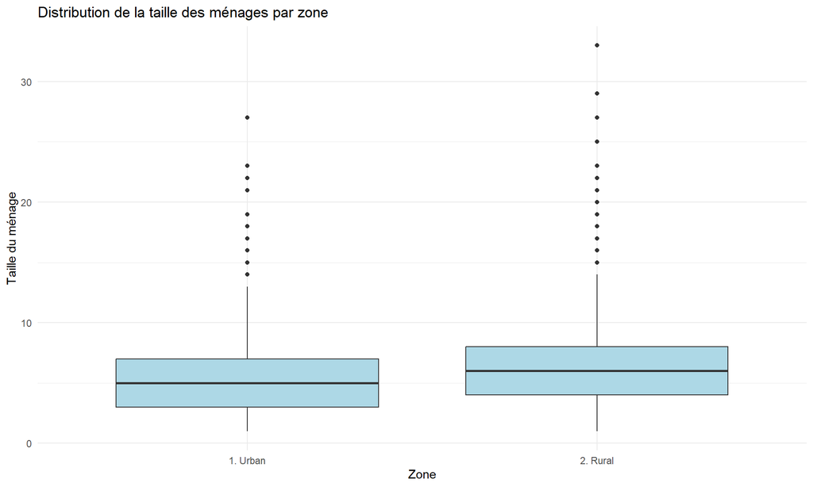

```r
ggplot(data_group, aes(x = as_factor(sector), y = taille_men)) +
  geom_boxplot(fill = "lightblue") +
  labs(
    title = "Distribution de la taille des ménages par zone",
    x = "Zone",
    y = "Taille du ménage"
  ) +
  theme_minimal()
```

nalyse : Le code crée un boxplot pour visualiser la taille des ménages selon la zone (sector) :

aes(x = as_factor(sector), y = taille_men) : l’axe x correspond aux zones, l’axe y à la taille des ménages.

geom_boxplot(fill = “lightblue”) : dessine des boîtes pour chaque zone, montrant médiane, quartiles et éventuelles valeurs extrêmes.

labs() et theme_minimal() : ajout du titre et style simple.

Interprétation :

La boîte montre la distribution de la taille des ménages dans chaque zone : médiane, 1er et 3e quartile.

Les points en dehors des boîtes indiquent des ménages très petits ou très grands (outliers).

On peut comparer facilement si certaines zones ont tendance à avoir des ménages plus grands ou plus petits ## Test statistique

```r
wilcox.test(taille_men ~ as_factor(sector), data = data_group)
```

```
##
##  Wilcoxon rank sum test with continuity correction
##
## data:  taille_men by as_factor(sector)
## W = 2307181, p-value < 2.2e-16
## alternative hypothesis: true location shift is not equal to 0
```

# Tableau récapitulatif stratifié par zone

## Préparation des données complètes

```r
data_2 <- data_2 %>% select(hhid, sector)
data <- inner_join(data, data_2, by = "hhid")

data <- data %>%
  group_by(hhid) %>%
  mutate(taille_men = n()) %>%
  ungroup()

data_tab <- data %>%
  select(hhid, s1q4, s1q2, taille_men, sector.y) %>%
  inner_join(data_2 %>% select(hhid, sector), by = "hhid") %>%
  mutate(
    sector = as_factor(sector),
    s1q2 = as_factor(s1q2)
  )
```

Analyse : Le code prépare un tableau final pour l’analyse en combinant les informations des individus et des ménages :

inner_join(data, data_2, by = “hhid”) : on ajoute les informations de zone à chaque individu.

group_by(hhid) %>% mutate(taille_men = n()) : calcule la taille de chaque ménage et l’ajoute à toutes les lignes correspondant à ce ménage.

data_tab <- … : crée un nouveau tableau avec :

hhid : identifiant du ménage

s1q4 : âge

s1q2 : sexe

taille_men : nombre de membres du ménage

sector : zone (convertie en facteur pour les analyses graphiques ou statistiques)

Interprétation :

Le tableau final data_tab contient toutes les informations essentielles pour analyser l’âge, le sexe et la taille des ménages selon la zone.

Il permet ensuite de produire statistiques descriptives, graphiques et comparaisons par zone. ## Tableau stratifié

```r
tab_resume <- data_tab %>%
  mutate(
    sector.y = haven::as_factor(sector.y),
    s1q2 = haven::as_factor(s1q2)
  ) %>%
  select(sector.y, s1q4, s1q2, taille_men) %>%
  tbl_summary(
    by = sector.y,
    label = list(
      s1q4 ~ "Âge",
      s1q2 ~ "Sexe",
      taille_men ~ "Taille du ménage"
    ),
    type = list(
      s1q4 ~ "continuous2",
      taille_men ~ "continuous2"
    ),
    statistic = list(
      all_continuous() ~ c("{mean} ({sd})", "{median} [{p25} ; {p75}]"),
      all_categorical() ~ "{n} ({p}%)"
    ),
    missing = "no"
  ) %>%
  add_p(
    test = list(
      s1q4 ~ "wilcox.test",
      s1q2 ~ "chisq.test",
      taille_men ~ "wilcox.test"
    )
  ) %>%
  bold_labels()

tab_resume
```

| **Characteristic** | **1. Urban** N = 8,719<sup>1</sup> | **2. Rural** N = 21,618<sup>1</sup> | **p-value**<sup>2</sup> |
| --- | --- | --- | --- |
| Âge |  |  | <0.001 |
| Mean (SD) | 25 (19) | 24 (20) |  |
| Median [Q1 ; Q3] | 19 [9 ; 38] | 17 [8 ; 35] |  |
| Sexe |  |  | 0.5 |
| 1. MALE | 3,730 (49%) | 9,459 (50%) |  |
| 2. FEMALE | 3,837 (51%) | 9,531 (50%) |  |
| Taille du ménage |  |  | <0.001 |
| Mean (SD) | 7 (4) | 9 (4) |  |
| Median [Q1 ; Q3] | 7 [5 ; 9] | 8 [6 ; 11] |  |

<sup>1</sup> n (%)  
<sup>2</sup> Wilcoxon rank sum test; Pearson’s Chi-squared test

Analyse : Le code crée un tableau résumé stratifié par zone (sector.y) avec le package gtsummary :

mutate(… as_factor …) : convertit les variables sector.y et s1q2 (Sexe) en facteurs pour l’analyse.

select(…) : garde les colonnes importantes pour le résumé : zone, âge, sexe et taille du ménage.

tbl_summary(…) : produit un tableau descriptif :

Pour les variables continues (s1q4 âge, taille_men) : moyenne (écart-type) et médiane [quartiles].

Pour les variables catégorielles (s1q2) : effectifs et pourcentages.

add_p(…) : ajoute les tests statistiques pour comparer les zones :

Âge et taille des ménages → test de Wilcoxon

Sexe → test du Chi²

bold_labels() : met en gras les noms des variables pour plus de lisibilité.

Interprétation :

Le tableau permet de comparer l’âge, le sexe et la taille des ménages selon la zone.

Les p-values indiquent si les différences observées entre zones sont statistiquement significatives.

Il constitue une synthèse complète et prête à être présentée, combinant descriptifs et tests comparatifs.